# Working with Databases - Part II

Biostat 203B

Dr. Hua Zhou @ UCLA

Feb 18, 2021

## Introduction

In this lecture we will learn:

- Import data from bigish csv files (MIMIC-III).
- Deposit data into an SQLite database.
- Query SQLite database.
- Transform in database and plot in R.

## Machine information

```r
library(tidyverse)
```

## CSV file

The `/usr/203b-data/mimic-iii` folder on the teaching server contains the MIMIC-III data.

```bash
# On teaching server
ls -l /usr/203b-data/mimic-iii
```

```
## total 11088356
## -rw-r--r--. 1 huazhou huazhou   12548562 Feb 18 18:12 ADMISSIONS.csv
## -rw-r--r--. 1 huazhou huazhou    6339185 Feb 18 18:12 CALLOUT.csv
## -rw-r--r--. 1 huazhou huazhou     203492 Feb 18 18:12 CAREGIVERS.csv
## -rw-r--r--. 1 huazhou huazhou   85204883 Feb 18 18:12 CHARTEVENTS.csv
## -rw-r--r--. 1 huazhou huazhou   58150883 Feb 18 18:12 CPTEVENTS.csv
## -rw-r--r--. 1 huazhou huazhou  525785298 Feb 18 18:14 DATETIMEEVENTS.csv
## -rw-r--r--. 1 huazhou huazhou      13807 Feb 18 18:14 D_CPT.csv
## -rw-r--r--. 1 huazhou huazhou   19137527 Feb 18 18:14 DIAGNOSES_ICD.csv
## -rw-r--r--. 1 huazhou huazhou    1387562 Feb 18 18:14 D_ICD_DIAGNOSES.csv
## -rw-r--r--. 1 huazhou huazhou     311466 Feb 18 18:14 D_ICD_PROCEDURES.csv
## -rw-r--r--. 1 huazhou huazhou     954420 Feb 18 18:14 D_ITEMS.csv
## -rw-r--r--. 1 huazhou huazhou      43118 Feb 18 18:14 D_LABITEMS.csv
## -rw-r--r--. 1 huazhou huazhou   10487132 Feb 18 18:14 DRGCODES.csv
## -rw-r--r--. 1 huazhou huazhou    6357077 Feb 18 18:14 ICUSTAYS.csv
## -rw-r--r--. 1 huazhou huazhou 2464296511 Feb 18 18:23 INPUTEVENTS_CV.csv
## -rw-r--r--. 1 huazhou huazhou  975255812 Feb 18 18:28 INPUTEVENTS_MV.csv
## -rw-r--r--. 1 huazhou huazhou 1854245647 Feb 18 18:35 LABEVENTS.csv
## -rw-r--r--. 1 huazhou huazhou   72507810 Feb 18 18:35 MICROBIOLOGYEVENTS.csv
## -rw-r--r--. 1 huazhou huazhou 4007717810 Feb 18 18:51 NOTEEVENTS.csv
## -rw-r--r--. 1 huazhou huazhou  396406750 Feb 18 18:53 OUTPUTEVENTS.csv
## -rw-r--r--. 1 huazhou huazhou    2628900 Feb 18 18:53 PATIENTS.csv
## -rw-r--r--. 1 huazhou huazhou  770336136 Feb 18 18:57 PRESCRIPTIONS.csv
## -rw-r--r--. 1 huazhou huazhou   48770424 Feb 18 18:57 PROCEDUREEVENTS_MV.csv
## -rw-r--r--. 1 huazhou huazhou    6798492 Feb 18 18:57 PROCEDURES_ICD.csv
## -rw-r--r--. 1 huazhou huazhou    3481645 Feb 18 18:57 SERVICES.csv
## -rw-r--r--. 1 huazhou huazhou   25057095 Feb 18 18:57 TRANSFERS.csv
```

On my Mac, it’s at `/Users/huazhou/Google Drive/mimic/mimic-iii`.

```r
datafolder <- ifelse(Sys.info()[["sysname"]] == "Linux",
                    "/usr/203b-data/mimic-iii",
                    "/Users/huazhou/Google\ Drive/mimic/mimic-iii")
list.files(datafolder, full.names = TRUE, patter = "*.csv")
```

```
##  [1] "/usr/203b-data/mimic-iii/ADMISSIONS.csv"
##  [2] "/usr/203b-data/mimic-iii/CALLOUT.csv"
##  [3] "/usr/203b-data/mimic-iii/CAREGIVERS.csv"
##  [4] "/usr/203b-data/mimic-iii/CHARTEVENTS.csv"
##  [5] "/usr/203b-data/mimic-iii/CPTEVENTS.csv"
##  [6] "/usr/203b-data/mimic-iii/D_CPT.csv"
##  [7] "/usr/203b-data/mimic-iii/D_ICD_DIAGNOSES.csv"
##  [8] "/usr/203b-data/mimic-iii/D_ICD_PROCEDURES.csv"
##  [9] "/usr/203b-data/mimic-iii/D_ITEMS.csv"
## [10] "/usr/203b-data/mimic-iii/D_LABITEMS.csv"
## [11] "/usr/203b-data/mimic-iii/DATETIMEEVENTS.csv"
## [12] "/usr/203b-data/mimic-iii/DIAGNOSES_ICD.csv"
## [13] "/usr/203b-data/mimic-iii/DRGCODES.csv"
## [14] "/usr/203b-data/mimic-iii/ICUSTAYS.csv"
## [15] "/usr/203b-data/mimic-iii/INPUTEVENTS_CV.csv"
## [16] "/usr/203b-data/mimic-iii/INPUTEVENTS_MV.csv"
## [17] "/usr/203b-data/mimic-iii/LABEVENTS.csv"
## [18] "/usr/203b-data/mimic-iii/MICROBIOLOGYEVENTS.csv"
## [19] "/usr/203b-data/mimic-iii/NOTEEVENTS.csv"
## [20] "/usr/203b-data/mimic-iii/OUTPUTEVENTS.csv"
## [21] "/usr/203b-data/mimic-iii/PATIENTS.csv"
## [22] "/usr/203b-data/mimic-iii/PRESCRIPTIONS.csv"
## [23] "/usr/203b-data/mimic-iii/PROCEDUREEVENTS_MV.csv"
## [24] "/usr/203b-data/mimic-iii/PROCEDURES_ICD.csv"
## [25] "/usr/203b-data/mimic-iii/SERVICES.csv"
## [26] "/usr/203b-data/mimic-iii/TRANSFERS.csv"
```

## Read csv file: `read.csv()` vs `read_csv()` (tidyverse) vs `fread()` (data.table)

In HW2, we learnt that the `fread()` function in the data.table package is much more efficient for parsing large text files than `read.csv()` in base R.

## Read all CSVs and deposit to an SQLite database

Create a SQLite database file called `mimiciii.sqlite`.

```r
library("DBI")
library("RSQLite")
```

Because of excellent efficiency of `data.table` packages, we use it to read all CSVs and deposit into `mimiciii.sqlite`. **Do not run this chunk by yourself on teaching server.** This takes a couple minutes.

```r
# establish connection to mimiciii.sqlite
con = dbConnect(RSQLite::SQLite(), "mimiciii.sqlite")
str(con)
# read in csv files and deposit them into mimiciii.sqlite
datafolder
csv_names <- list.files(datafolder)
csv_names <- csv_names[str_detect(csv_names, "csv")]
csv_names
system.time({
for (table_name in csv_names) {
    csv_name <- str_c(datafolder, "/", table_name)
    tmp <- fread(csv_name)
    table_name <- str_remove(table_name, ".csv")
    dbWriteTable(con, table_name, tmp, overwrite = TRUE)
}})
# list tables in database
dbListTables(con)
# disconnect from database
dbDisconnect(con)
```

The resultant database file `mimiciii.sqlite` has size 10.4GB.

On the teaching server, this file is located at `/usr/203b-data/mimic-iii-db/`.

```bash
ls -l /usr/203b-data/mimic-iii-db/mimiciii.sqlite
```

```
## -rw-r--r--. 1 huazhou huazhou 11160363008 Feb 18 19:49 /usr/203b-data/mimic-iii-db/mimiciii.sqlite
```

## Read data from database

Connect to the database `mimiciii.sqlite` and list the tables:

```r
con <- dbConnect(RSQLite::SQLite(),
                 dbname = ifelse(Sys.info()[["sysname"]] == "Linux",
                    "/usr/203b-data/mimic-iii-db/mimiciii.sqlite",
                    "./mimiciii.sqlite"))
dbListTables(con)
```

```
##  [1] "ADMISSIONS"         "CALLOUT"            "CAREGIVERS"
##  [4] "CHARTEVENTS"        "CPTEVENTS"          "DATETIMEEVENTS"
##  [7] "DIAGNOSES_ICD"      "DRGCODES"           "D_CPT"
## [10] "D_ICD_DIAGNOSES"    "D_ICD_PROCEDURES"   "D_ITEMS"
## [13] "D_LABITEMS"         "ICUSTAYS"           "INPUTEVENTS_CV"
## [16] "INPUTEVENTS_MV"     "LABEVENTS"          "MICROBIOLOGYEVENTS"
## [19] "NOTEEVENTS"         "OUTPUTEVENTS"       "PATIENTS"
## [22] "PRESCRIPTIONS"      "PROCEDUREEVENTS_MV" "PROCEDURES_ICD"
## [25] "SERVICES"           "TRANSFERS"
```

Read the table `CHARTEVENTS`:

```r
chartevents <- tbl(con, "CHARTEVENTS")
class(chartevents)
```

```
## [1] "tbl_SQLiteConnection" "tbl_dbi"              "tbl_sql"
## [4] "tbl_lazy"             "tbl"
```

```r
chartevents %>% print(width = Inf)
```

```
## # Source:   table<CHARTEVENTS> [?? x 15]
## # Database: sqlite 3.34.1 [/usr/203b-data/mimic-iii-db/mimiciii.sqlite]
##    ROW_ID SUBJECT_ID HADM_ID ICUSTAY_ID ITEMID CHARTTIME     STORETIME      CGID
##     <int>      <int>   <int>      <int>  <int> <chr>         <chr>         <int>
##  1    788         36  165660     241249 223834 5/12/34 12:00 5/12/34 13:56 17525
##  2    789         36  165660     241249 223835 5/12/34 12:00 5/12/34 13:56 17525
##  3    790         36  165660     241249 224328 5/12/34 12:00 5/12/34 12:18 20823
##  4    791         36  165660     241249 224329 5/12/34 12:00 5/12/34 12:19 20823
##  5    792         36  165660     241249 224330 5/12/34 12:00 5/12/34 12:19 20823
##  6    793         36  165660     241249 224331 5/12/34 12:00 5/12/34 12:19 20823
##  7    794         36  165660     241249 224332 5/12/34 12:00 5/12/34 14:44 17525
##  8    795         36  165660     241249 224663 5/12/34 12:00 5/12/34 14:44 17525
##  9    796         36  165660     241249 224665 5/12/34 12:00 5/12/34 14:44 17525
## 10    797         36  165660     241249 220224 5/12/34 12:35 5/12/34 12:38 20889
##     VALUE VALUENUM VALUEUOM WARNING ERROR RESULTSTATUS STOPPED
##     <dbl>    <dbl> <chr>      <int> <int>        <int>   <int>
##  1  15       15    "L/min"        0     0           NA      NA
##  2 100      100    ""             0     0           NA      NA
##  3   0.37     0.37 ""             0     0           NA      NA
##  4   6        6    "min"          0     0           NA      NA
##  5   2.5      2.5  ""             0     0           NA      NA
##  6   0        0    "ml/hr"        0     0           NA      NA
##  7   3        3    ""             0     0           NA      NA
##  8   8        8    ""             0     0           NA      NA
##  9   1.11     1.11 ""             0     0           NA      NA
## 10  58       58    "mmHg"         1     0           NA      NA
## # … with more rows
```

## Use dplyr with SQLite

```r
chartevents_subset <- chartevents %>%
  select(ROW_ID, SUBJECT_ID, HADM_ID, ITEMID, ITEMID) %>%
  filter(SUBJECT_ID >= 23, SUBJECT_ID <= 165)
chartevents_subset
```

```
## # Source:   lazy query [?? x 4]
## # Database: sqlite 3.34.1 [/usr/203b-data/mimic-iii-db/mimiciii.sqlite]
##    ROW_ID SUBJECT_ID HADM_ID ITEMID
##     <int>      <int>   <int>  <int>
##  1    788         36  165660 223834
##  2    789         36  165660 223835
##  3    790         36  165660 224328
##  4    791         36  165660 224329
##  5    792         36  165660 224330
##  6    793         36  165660 224331
##  7    794         36  165660 224332
##  8    795         36  165660 224663
##  9    796         36  165660 224665
## 10    797         36  165660 220224
## # … with more rows
```

## SQL query

```r
class(chartevents_subset)
```

```
## [1] "tbl_SQLiteConnection" "tbl_dbi"              "tbl_sql"
## [4] "tbl_lazy"             "tbl"
```

```r
show_query(chartevents_subset)
```

```
## <SQL>
## SELECT *
## FROM (SELECT `ROW_ID`, `SUBJECT_ID`, `HADM_ID`, `ITEMID`
## FROM `CHARTEVENTS`)
## WHERE ((`SUBJECT_ID` >= 23.0) AND (`SUBJECT_ID` <= 165.0))
```

## SQL grouping

```r
chartevents %>%
  group_by(SUBJECT_ID) %>%
  summarise(n = n())
```

```
## # Source:   lazy query [?? x 2]
## # Database: sqlite 3.34.1 [/usr/203b-data/mimic-iii-db/mimiciii.sqlite]
##    SUBJECT_ID     n
##         <int> <int>
##  1         23   320
##  2         34   346
##  3         36  1342
##  4         85   396
##  5        107   763
##  6        109 12471
##  7        111   351
##  8        124 10712
##  9        154   422
## 10        165   217
## # … with more rows
```

## SQL query

```r
chartevents %>%
  group_by(SUBJECT_ID) %>%
  summarise(n = n()) %>%
  show_query()
```

```
## <SQL>
## SELECT `SUBJECT_ID`, COUNT(*) AS `n`
## FROM `CHARTEVENTS`
## GROUP BY `SUBJECT_ID`
```

## SQL translation

dbplyr package (a dplyr backend for databases) has a function, `translate_sql`, that lets you experiment with how R functions are translated to SQL:

```r
library("dbplyr")
translate_sql(x == 1 & (y < 2 | z > 3))
```

```
## <SQL> `x` = 1.0 AND (`y` < 2.0 OR `z` > 3.0)
```

```r
translate_sql(x ^ 2 < 10)
```

```
## <SQL> POWER(`x`, 2.0) < 10.0
```

```r
translate_sql(x %% 2 == 10)
```

```
## <SQL> `x` % 2.0 = 10.0
```

```r
translate_sql(paste(x, y))
```

```
## <SQL> CONCAT_WS(' ', `x`, `y`)
```

```r
translate_sql(mean(x))
```

```
## <SQL> AVG(`x`) OVER ()
```

```r
translate_sql(mean(x, na.rm = TRUE))
```

```
## <SQL> AVG(`x`) OVER ()
```

## Timings

Let’s compare the timings of dplyr (in-momory) and dbplyr (on disk database).

- dplyr using tibble:

```r
csvfile <- str_c(datafolder, "/DATETIMEEVENTS.csv")
dtevents_tibble <- read_csv(csvfile)
system.time(
  dtevents_tibble %>%
  select(ROW_ID, SUBJECT_ID, HADM_ID, ITEMID) %>%
  # filter(SUBJECT_ID >= 23, SUBJECT_ID <= 165) %>%
  group_by(SUBJECT_ID) %>%
  summarize(n = n())
)
```

```
##    user  system elapsed
##   0.612   0.074   0.691
```

- dplyr using SQLite:

```r
dtevents_sql <- tbl(con, "DATETIMEEVENTS")
system.time(
  dtevents_sql %>%
  select(ROW_ID, SUBJECT_ID, HADM_ID, ITEMID) %>%
  # filter(SUBJECT_ID >= 23, SUBJECT_ID <= 165) %>%
  group_by(SUBJECT_ID) %>%
  summarize(n = n())
)
```

```
##    user  system elapsed
##   0.006   0.000   0.006
```

## Laziness

dplyr/dbplyr uses lazy evaluation as much as possible, particularly when working with non-local backends.

- When building a query, we don’t want the entire table, often we want just enough to check if our query is working.
- Since we would prefer to run one complex query over many simple queries, laziness allows for verbs to be strung together.
- Therefore, by default dplyr
  - won’t connect and query the database until absolutely necessary (e.g. show output),
  - and unless explicitly told to, will only query a handful of rows to give a sense of what the result will look like

```r
dtevents_sql %>%
  select(ROW_ID, SUBJECT_ID, HADM_ID, ITEMID) %>%
  # filter(SUBJECT_ID >= 23, SUBJECT_ID <= 165) %>%
  group_by(SUBJECT_ID) %>%
  summarize(n = n())
```

```
## # Source:   lazy query [?? x 2]
## # Database: sqlite 3.34.1 [/usr/203b-data/mimic-iii-db/mimiciii.sqlite]
##    SUBJECT_ID     n
##         <int> <int>
##  1          6    60
##  2          8     5
##  3         17    69
##  4         21   259
##  5         23    18
##  6         25     2
##  7         34    27
##  8         35   141
##  9         36   201
## 10         38   877
## # … with more rows
```

## Full query

To force a full query and return a complete table it is necessary to use the `collect` function.

```r
system.time(
  dtevents_sql %>%
  select(ROW_ID, SUBJECT_ID, HADM_ID, ITEMID) %>%
  # filter(SUBJECT_ID >= 23, SUBJECT_ID <= 165) %>%
  group_by(SUBJECT_ID) %>%
  summarize(n = n()) %>%
  collect()
)
```

```
##    user  system elapsed
##   1.978   0.364   2.344
```

## Plotting

### Bar plot

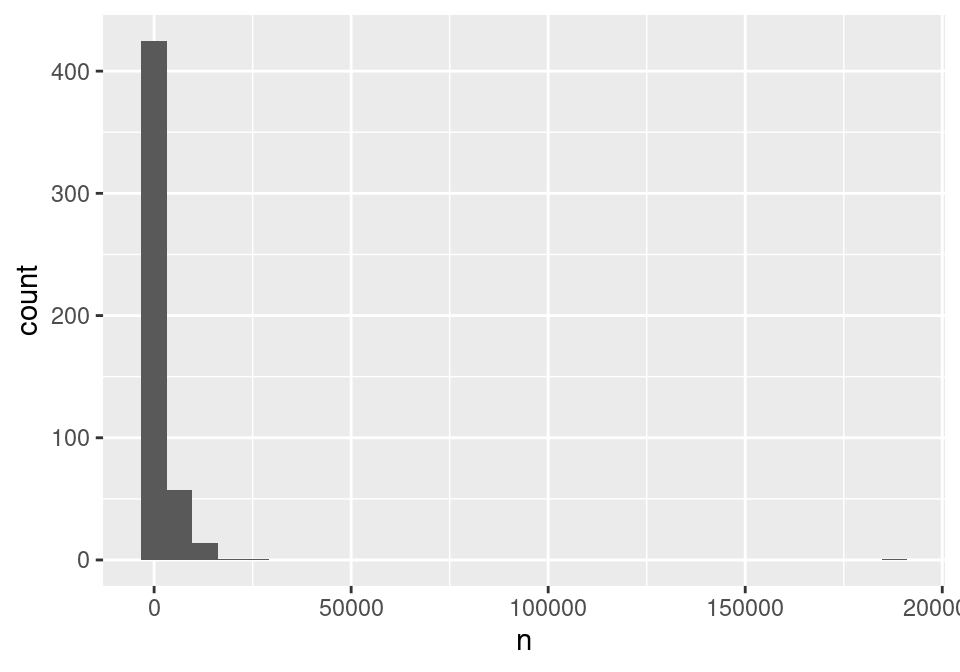

```r
chartevents %>%
  count(SUBJECT_ID) %>%
  ggplot() +
  geom_histogram(mapping = aes(x = n))
```

Apparently current version of ggplot2 (v3.2.1) works for `tbl_dbi/tbl_sql/tbl_lazy` now.

Older version of ggplot2, e.g., v2.2.1, will output error. This is becasue ggplot2 needed to compute the count per bin by going through all the rows. But here `chartevents` is just a pointer to the SQLite table. We had to use the **transform in database, plot in R** strategy.

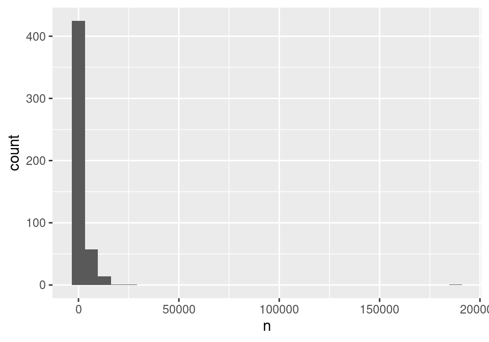

```r
chartevents %>%
  count(SUBJECT_ID) %>%
  collect() %>%
  ggplot() +
  geom_histogram(mapping = aes(x = n))
```

### Other plots

For example of making histogram and raster plot, read tutorial https://db.rstudio.com/best-practices/visualization/.

## Close connection to database

```r
dbDisconnect(con)
```